# sherlock-holmes-sentiment-analysis

Michael Lemke

3/27/2018

## Introduction

Welcome to a fun filled sentiment analysis of Sherlock Holmes and the Baker Street Irregulars in Search of Watson. We have a few goals for this activity:

1. **Load Stuff**
   - First we need the text to analyze
   - Then we need our special R libraries for determining sentiment
   - Last we need to load a few user defined functions (UDFs) that I wrote to make the code more readable
2. **Chop Stuff**
   - How do you chop stuff?
   - Chop the book into chapters
   - Chop the book into sentences
3. **Find Stuff**
   - Finding words
4. **Count Stuff**
   - Count Words
   - Count Features
5. **Visualize Stuff**
   - Drawing a Wordcloud
   - Ploting Bar Charts
6. **What is a Sentiment?**
   - Name some feelings
   - Reviewing the sentiment list
   - Mapping sentiments to text
   - Counting sentiments
   - Plotting
   - Drawing Conclusions

## Let’s Load Stuff

```r
# Load text from book
sherlock_holmes <- readLines("https://raw.githubusercontent.com/decart83/sherlock-holmes-sentiment-analysis/master/corpus.txt")

# Load User Defined Functions
source("https://raw.githubusercontent.com/decart83/sherlock-holmes-sentiment-analysis/master/functions.R")
```

## Chopping Stuff

Now that we have our text imported into R and our libraries loaded, we are ready to have some fun! We begin by chopping the text into the parts we would like to analyze.

```r
# What is chopping? Well, let's take a string, any string.
very_crazy_text <- "ababsteveaba.ba|babcatab"

# Just to check, let's print the sting
very_crazy_text
```

```
## [1] "ababsteveaba.ba|babcatab"
```

```r
# Start chopping with a delimiter
print(str_split(very_crazy_text, "b"))
```

```
## [[1]]
## [1] "a"      "a"      "stevea" "a."     "a|"     "a"      "cata"   ""
```

### Q: What other delimeters could we used?

### Q: What delimeters are meaningful?

## Let’s chop for real!

```r
# Split sherlock_holmes into chapters
sherlock_holmes_chapters <- str_split(sherlock_holmes, "Chapter ")[[1]]

# Corrent for "" in sherlock_holmes[1] which fixes the chapter index
sherlock_holmes_chapters <- sherlock_holmes_chapters[nzchar(x=sherlock_holmes_chapters)]

# Print Chapter 1
sherlock_holmes_chapters[1]
```

```
## [1] "1 %Death at the Museum% In the semi-round reading room of the British Museum Library, Calico Finch studied the centuries-old manuscript almost angrily. He ran a silver pointer across a line and cleared his throat with a growl. He translated and mumbled under his breath before tossing the man…
```

```r
# Split sherlock_holmes into sentences
sherlock_holmes_sentences <- str_split(sherlock_holmes, "[.]")[[1]]

# Corrent for "" in sherlock_holmes[1] which fixes the chapter index
sherlock_holmes_sentences <- sherlock_holmes_sentences[nzchar(x=sherlock_holmes_sentences)]

# Print first sentence
sherlock_holmes_sentences[1]
```

```
## [1] "Chapter 1 %Death at the Museum% In the semi-round reading room of the British Museum Library, Calico Finch studied the centuries-old manuscript almost angrily"
```

### Q: What is going on with line 10? Did it work?

### Q: What is going on with line 70 and 71?

### Q: What is going on with line 132? Is that a sentence?

## Find Stuff

```r
# Find stuff in the chapters
grep("cottage",sherlock_holmes_chapters, value=T)
```

```
## [1] "2 %Ozzie Searches for his Father% In a thatched-roof cottage in Wroxton, England, Manning studied his great-aunt Agatha. She was resting in an overstuffed armchair by a large stone fireplace. The earthy smell of charred logs filled the room.Ozzie prayed for the slightest tremor of understand…
```

```r
# Well that sucked... Let's try finding sentences that contain a word
grep("cottage",sherlock_holmes_sentences, value=T)
```

```
## [1] "\" -—- Page 6 —-- Chapter 2 %Ozzie Searches for his Father% In a thatched-roof cottage in Wroxton, England, Manning studied his great-aunt Agatha"
## [2] " Bentley in a cottage outside the gate of Wroxton Abbey and looked just the same as he remembered: a well-preserved woman in her eighties with gentle blue eyes and soft powdered skin"
## [3] "From upstairs in the cottage, Ozzie heard Mrs"
```

# Count Stuff

```r
# Count how many sentences have the word wood in them
#find line
length(grep("cottage",sherlock_holmes_sentences, value=T))
```

```
## [1] 3
```

```r
#Print Emotional Counts
titles <- c("Chapters")
books <- list(sherlock_holmes)
print_em_counts(titles,books)
```

```
## # A tibble: 10 x 2
##       sentiment     n
##           <chr> <int>
##  1     negative  3738
##  2     positive  2915
##  3         fear  1664
##  4        trust  1584
##  5        anger  1407
##  6      sadness  1382
##  7      disgust  1154
##  8 anticipation  1081
##  9          joy   845
## 10     surprise   637
```

### Q: What is the length that we are counting? The lenght of Wiggins arm, the word wood, the width of the classroom, what is it measuring?

### Q: Can you find how many times Wiggins appears? What about Pilar? Who is more?

### Q: How do we count everything?

## Visualize Stuff

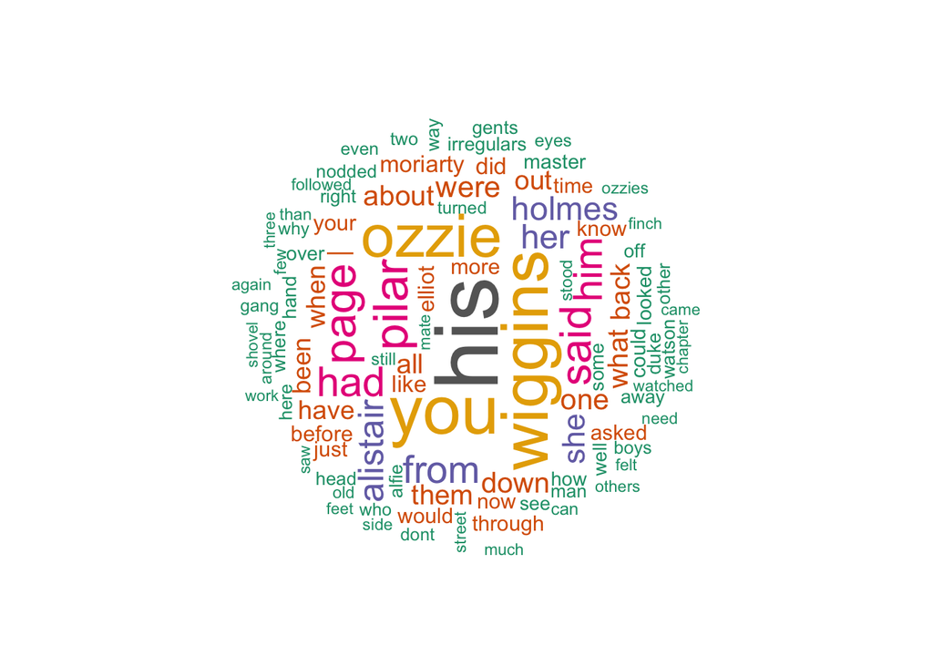

```r
# Wordcloud
# quick_wordcloud(text, remove words, filter text for)
quick_wordcloud(sherlock_holmes_sentences, c(""), c(""))
```

[figure not shown]

```r
# Climax
par(mfrow=c(2,2))
titles <- c("All", "Ch 3", "Ch 18-20","Ch 21-22")
books <- list(sherlock_holmes, sherlock_holmes[4], sherlock_holmes[19:21],sherlock_holmes[22:23])
sentiment_graph(titles, books)
```

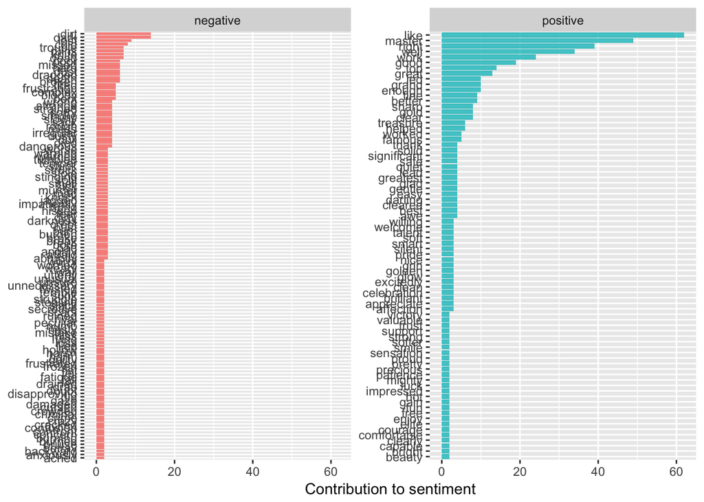

```r
# Bar chart of pos and neg words
bar_chart_em_freq(titles,books)
```

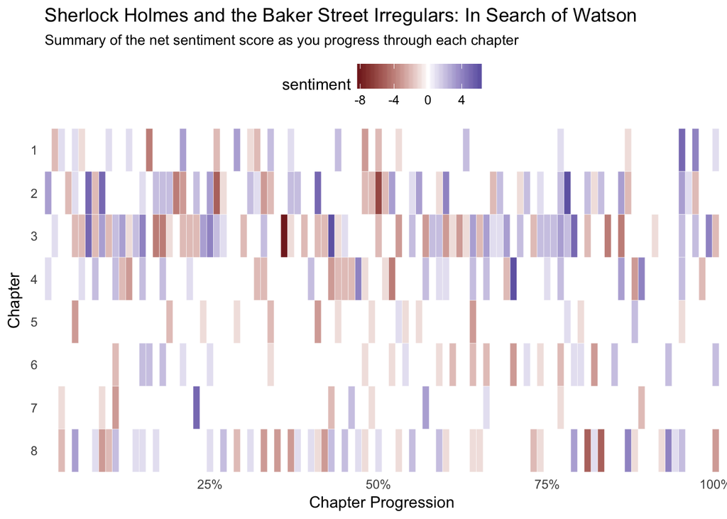

```r
# Whole book sentiment
book_sent(sherlock_holmes_chapters[1:8])
```

## What is a Sentiment?

```r
# What are sentiments?
sentiments
```

```
## # A tibble: 27,314 x 4
##           word sentiment lexicon score
##          <chr>     <chr>   <chr> <int>
##  1      abacus     trust     nrc    NA
##  2     abandon      fear     nrc    NA
##  3     abandon  negative     nrc    NA
##  4     abandon   sadness     nrc    NA
##  5   abandoned     anger     nrc    NA
##  6   abandoned      fear     nrc    NA
##  7   abandoned  negative     nrc    NA
##  8   abandoned   sadness     nrc    NA
##  9 abandonment     anger     nrc    NA
## 10 abandonment      fear     nrc    NA
## # ... with 27,304 more rows
```

```r
# Sentiments values
get_sentiments("bing")
```

```
## # A tibble: 6,788 x 2
##           word sentiment
##          <chr>     <chr>
##  1     2-faced  negative
##  2     2-faces  negative
##  3          a+  positive
##  4    abnormal  negative
##  5     abolish  negative
##  6  abominable  negative
##  7  abominably  negative
##  8   abominate  negative
##  9 abomination  negative
## 10       abort  negative
## # ... with 6,778 more rows
```